# Lecture 16 - Multivariate Statistics

Author

Bill Perry

# Introduction to Multivariate Statistics

## Overview

- Multivariate data: multiple variables per object
- Types of multivariate analyses
  - Functional vs. structural methods
  - R-mode vs. Q-mode analyses
- Eigenvectors, eigenvalues, and components
- Distance and dissimilarity measures
- Data transformations and standardization
- Screening multivariate data
- MANOVA

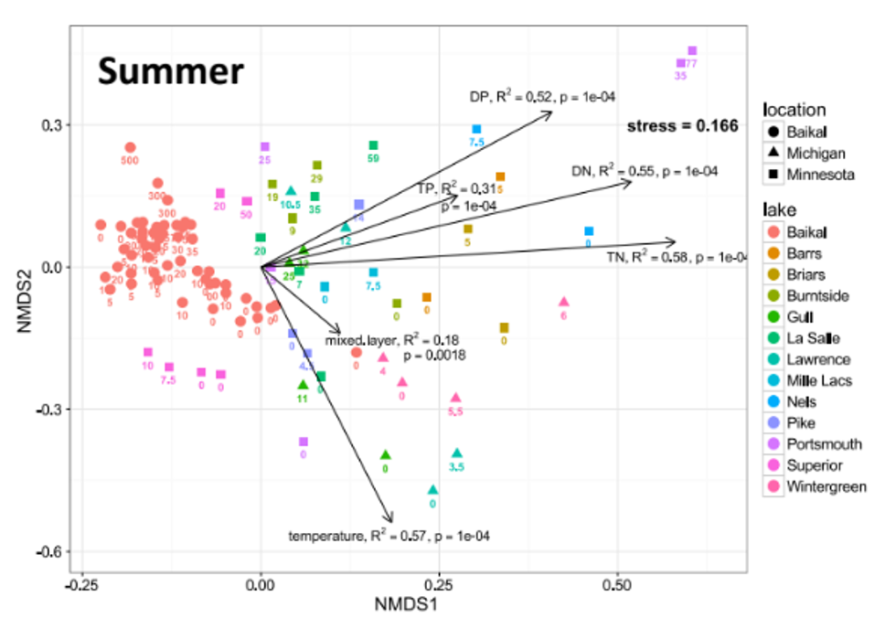

# Multivariate Data Structure

- Multiple variables recorded about each object (individual, quadrat, site, etc.)
  - or responses that are from the same treatment factor
  - length, weight, width, color, spines, etc
- Objects: rows (i = 1 to n)
- Variables: columns (j = 1 to p)
- Examples:
  - Stream sites with multiple chemical parameters
  - Species with multiple morphological traits
  - Sample units with multiple species abundances

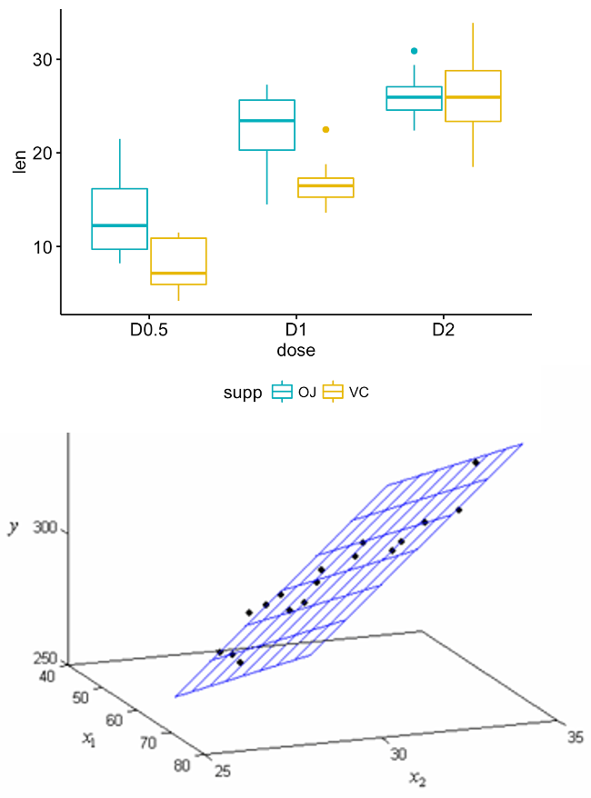

**Multivariate data vs. multivariate analysis**

We’ve already seen multivariate data in multiple regression and multi-factor ANOVA

**Now we’ll look at cases with multiple response variables.**

# Functional vs. Structural Methods

## Functional vs. Structural Methods

**Functional methods**: - Clear response and predictor variables - Goal: relate Y’s to X’s - Examples: MANOVA, PERMANOVA

**Structural methods**: - Find patterns/structure in data - Often no clear predictors - Examples: PCA, NMDS, Cluster Analysis

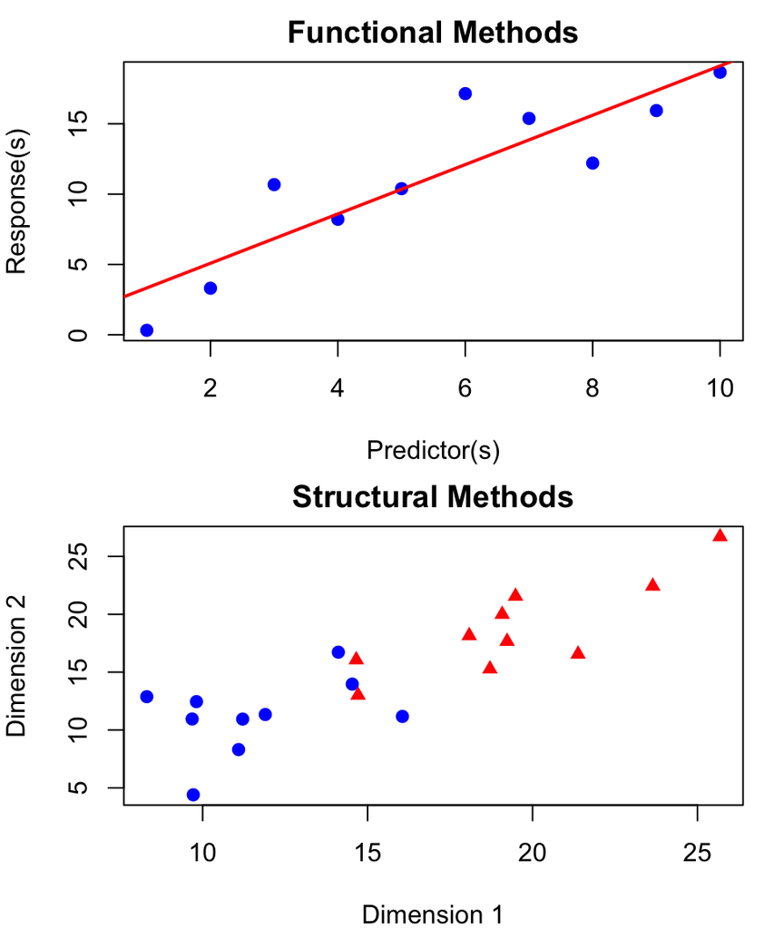

# Functional Methods Examples

Example 1:

- sample 30 stream sites (objects)
- record TP, TN, pH, DO, chloride concentration, etc.
- each parameter is a variable

Example 2:

- sample 30 stream sites (objects)
- collect benthic invertebrates
- each species is now a variable

Sometimes combine both…

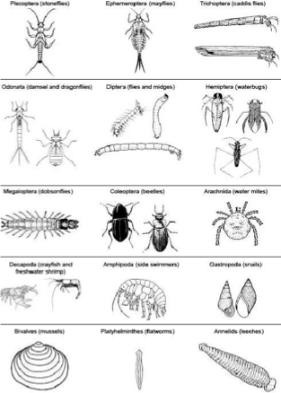

# Functional Methods Visualization

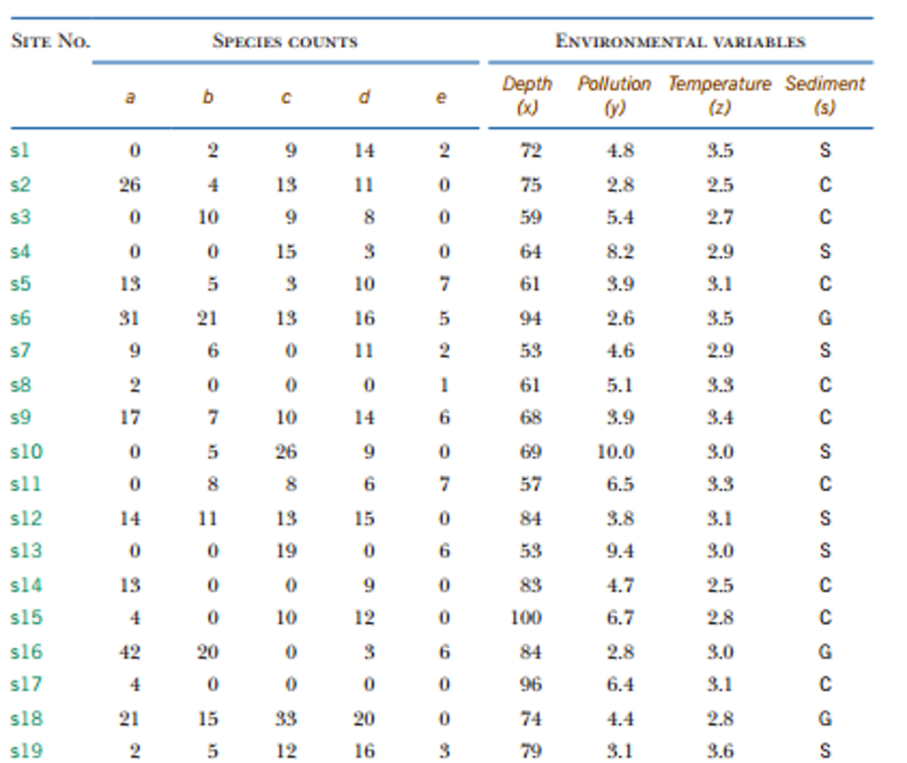

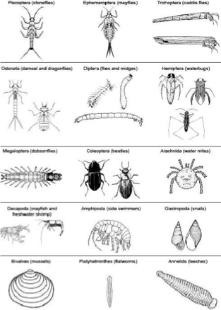

# Ecological Multivariate Methods Overview

Can divide ecological MV methods into “functional” and “structural”

- Functional methods: clear response variable(s) and predictor variables. Goal is to relate Ys to Xs (regression, MANOVA, ANOSIM, PERMANOVA).
- Structural methods: concerned with finding structure /pattern in the data. Often no clear predictor variables (PCA, NMDS, Cluster analysis).

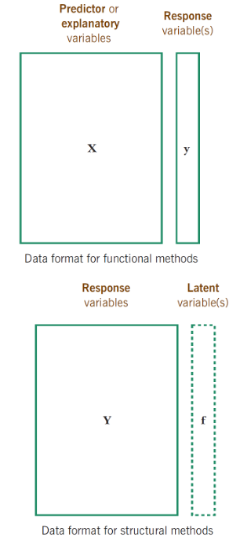

# Structural Methods: Two Approaches

## Two Main Approaches

**Scaling/Ordination Methods**: - Reduce dimensions with new derived variables - Summarize patterns in data - Examples: PCA, CCA

**Dissimilarity-Based Methods**: - Measure dissimilarity between objects - Visualize relationships between objects - Examples: NMDS, Cluster Analysis

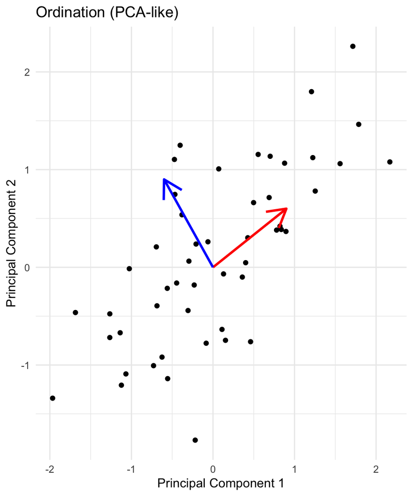

# Structural Methods: Scaling/Ordination

Structural methods can be divided further into:

Methods based on scaling or ordination

Goal: reduce number of vars by deriving new variables that summarize data.

Examples include PCA, CCA

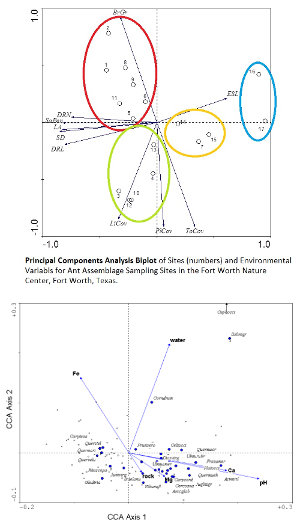

# Structural Methods: Dissimilarity-Based

Structural methods can be divided further into:

- Methods based on dissimilarity measurements
- Goal: measure and graphically show degree of dissimilarity between objects.
- Examples include (N)MDS and cluster analysis

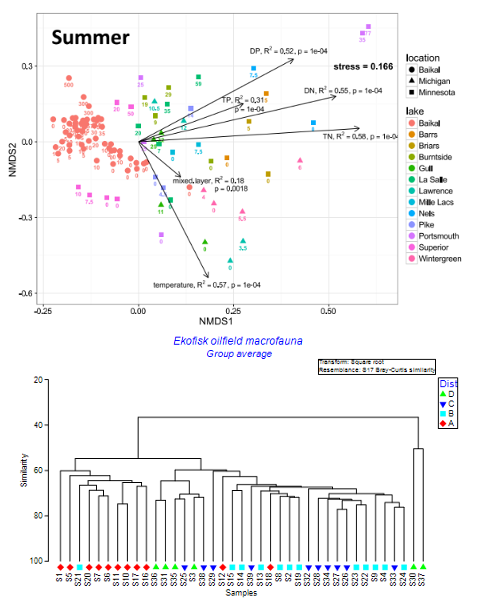

# Eigenvectors, Eigenvalues, and Components: Concept

- Goal: derive new variables (principal components) that explain variation in data
- Components are linear combinations of original variables:
  - z<sub>ik</sub> = c<sub>1</sub>y<sub>i1</sub> + c<sub>2</sub>y<sub>i2</sub> + … + c<sub>p</sub>y<sub>ip</sub>
- Properties of derived variables:
  - First component explains most variation
  - Second explains most remaining variation
  - Components are uncorrelated with each other
  - As many components as original variables

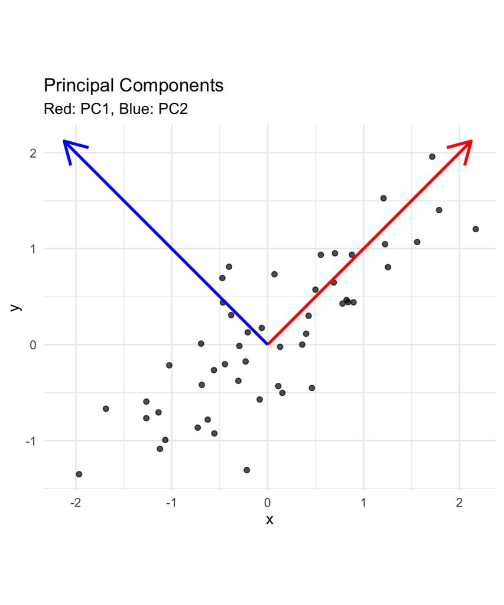

# Eigenvectors and Components: Interpretation

How to think about the new values

- zik is value of new variable k for object I
- yi1- yip are values of original variables for object i
- c1-cp are coefficients that show importance of the original variables to new derived variable

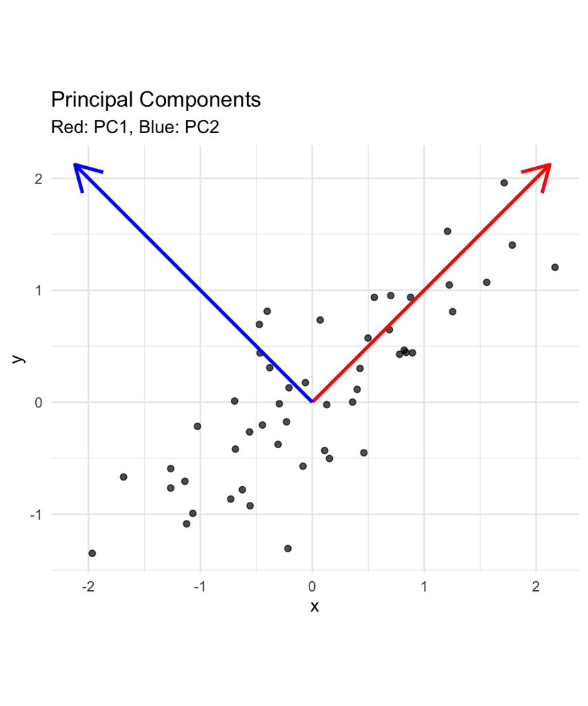

**Key concept**

Eigenvalues (λ) represent the amount of variation explained by each new derived variable, while eigenvectors contain the coefficients showing how original variables contribute to each component.

# Eigenvalues and Components: Properties

Derived variables are found so that:

- First derived variable explains most of the variation in the data
- Second most of the remaining variation
- And so on…
- As many derived variables as original variables (p)
- Derived variables are uncorrelated with each other

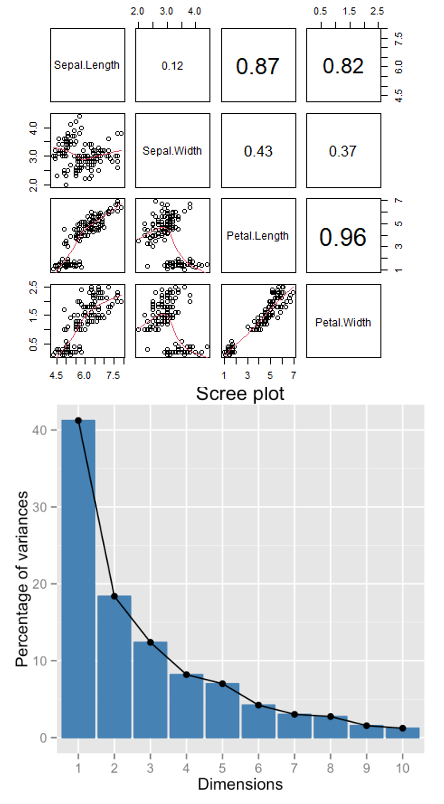

# Eigenvalues and Eigenvectors: Mathematical Details

- Eigenvalues (latent roots) represent amount of variation in data explained by the new k= 1 to p derived variables (λ1, λ2 …λp).
- Eigenvalues are population parameters and are estimated using ML to get sample statistics (l1, l2…lp)
- Eigenvectors are lists of coefficients (c) that show contribution of original variables to new, derived variables
- Each new variable has an eigenvalue and an eigenvector
- New variables (components) are derived from a p x p covariance or correlation matrix of original variables

# Eigenvalue Matrix Representation

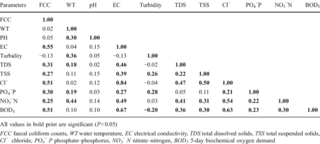

# Distance and Dissimilarity Measures: Concept

- Measure how different objects are in multivariate space
- Common measures:
  - **Euclidean distance**: direct geometric distance
  - **Manhattan distance**: sum of absolute differences
  - **Bray-Curtis**: good for species abundance data
  - **Kulczynski**: for abundance data with zeros
- Used in cluster analysis, MDS, and other techniques
- Create dissimilarity matrices for analysis

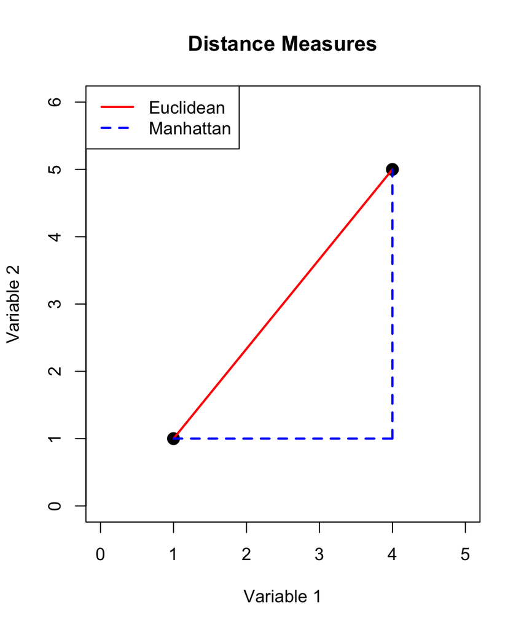

# Distance and Dissimilarity: Background

- Previous approach relies on analysis of covariance/ correlation bw variables
- Another class of MV analysis uses measures of similarity/dissimilarity bw objects (MDS, cluster analysis)
- Similarity/dissimilarity indices measure how alike/different objects (e.g. Lakes) are in MV space
- Many measures of dissimilarity (Euclidean, Manhattan, Bray-Curtis, etc, etc)

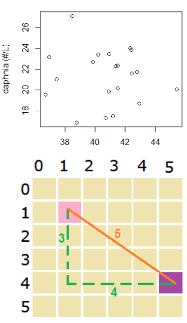

# Dissimilarity Matrix Representation

Dissimilarity is often represented as a dissimilarity matrix

[figure not shown]

# Data Transformations: Common Approaches

Data transformation is common and useful in MV analyses

- Log transformation is common in PCA/CCA analyses based on eigenvectors, since linearizing relationships bw variables will improve extraction of eigenvectors
- Fourth root transform is very common and sometimes “blanket recommended” for analysis of species composition data (each variable is a species w counts- MDS, cluster analysis). Idea is to lessen importance of common and abundant species

# Data Standardization: Methods

- Data standardization is also common; adjusts data so all variables have same means and/or variance
  - Centering- mean subtracted from each value (new mean=0)
  - Standardization- centered observations divided by SD (mean=0, sd=1)
- Crucial for analyses of variables measured in different units
- More ambiguous for species abundance data

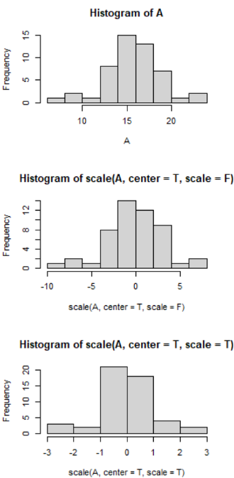

# Data Transformations & Standardization: Visual

## Common Approaches

**Transformations**: - Log transformation for skewed data - Root transformations for count data  
- Fourth-root for species abundance data

**Standardization**: - Centering: subtract mean (mean = 0) - Standardization: divide by SD (SD = 1) - Crucial for variables with different units - May not be appropriate for species data

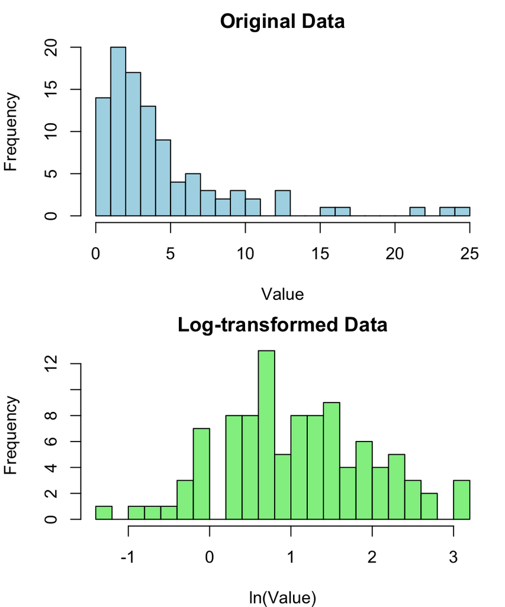

**Why standardize?**

Standardization ensures all variables contribute equally to the analysis regardless of their original units or scales of measurement. Without it, variables with larger values or variances would dominate the results.

# Multivariate Graphics Options

## Visual Representation Methods

- **SPLOMS/Scatterplot Matrices**: show bivariate relationships
- **Star plots**: display multiple variables per object
- **Chernoff faces**: represent variables as facial features
- **Heatmaps**: visualize data matrices with color
- **Biplots**: show objects and variables together
- **Ordination plots**: visualize relationships in reduced dimensions

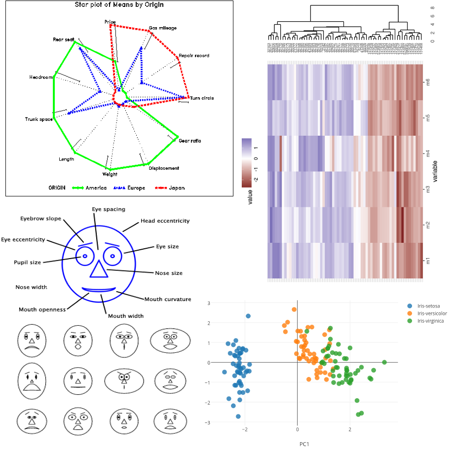

# Screening Multivariate Data: Outliers and Missing Data

## Key Issues to Check

**Multivariate Outliers**: - Objects with unusual patterns across variables - Detected with Mahalanobis distance (d²) - Test against χ² distribution with p df

**Missing Observations**: - Common approaches: - Deletion: remove affected object or variable - Imputation: estimate missing values - Maximum likelihood methods - Multiple imputation

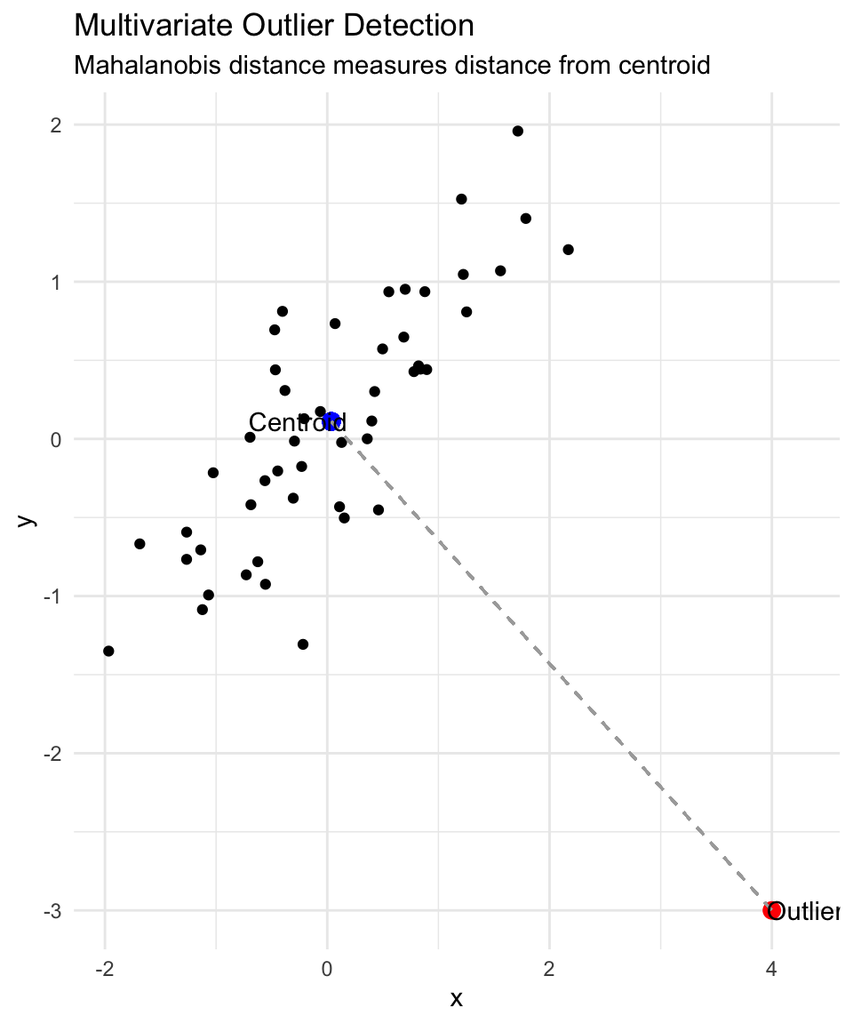

# MANOVA: Introduction

- Multivariate extension of ANOVA
- Tests for differences in group centroids based on multiple response variables
- Advantages over multiple ANOVAs:
  - Controls family-wise error rate
  - Accounts for correlations between variables
  - More powerful when variables are correlated
- Common test statistics:
  - Wilk’s lambda (λ)
  - Pillai’s trace
  - Hotelling-Lawley trace
- Famous dataframe built into R is the iris dataset

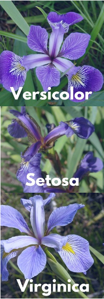

# MANOVA: Iris Dataset Example

Morphometric measurements on n=150 flowers

Response vars: Septal length + width, petal length + width

Predictor variable: species

Question: are there differences bw species?

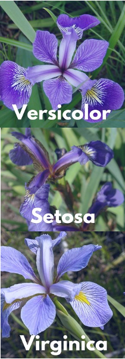

# MANOVA: Data Structure

Morphometric measurements on n=150 flowers

Response vars: Septal length + width, petal length + width

Predictor variable: species

Question: are there differences bw species?

```r
iris_df <- iris %>% clean_names()
iris_long_df <- iris_df %>% pivot_longer(cols = -species,
               names_to = "variable",
               values_to = "measure")
write_csv(iris_df, "data/iris.csv")
head(iris_df)
```

```
  sepal_length sepal_width petal_length petal_width species
1          5.1         3.5          1.4         0.2  setosa
2          4.9         3.0          1.4         0.2  setosa
3          4.7         3.2          1.3         0.2  setosa
4          4.6         3.1          1.5         0.2  setosa
5          5.0         3.6          1.4         0.2  setosa
6          5.4         3.9          1.7         0.4  setosa
```

# MANOVA: Data Visualization

Morphometric measurements on n=150 flowers

Response vars: Septal length + width, petal length + width

Predictor variable: species

Question: are there differences bw species?

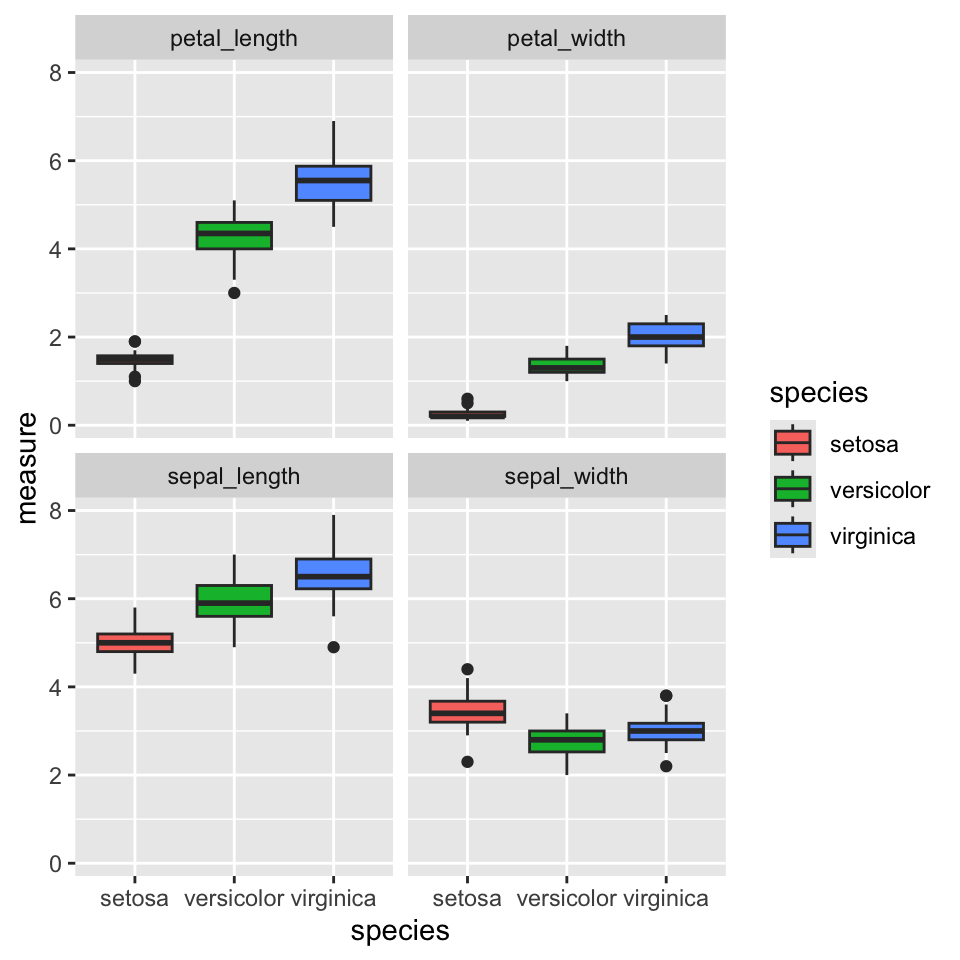

```r
iris_long_df %>% ggplot(aes(species, measure, fill=species))+
  geom_boxplot()+
  facet_wrap(.~variable)
```

# MANOVA vs. Multiple ANOVAs

One approach:

series of 1-way ANOVAs

for example —>

But:

- Variables and tests are not independent
- Multiple testing problem can reduce power
- MANOVA considers all response variables simultaneously

```r
sepal_model <- aov(sepal_length~species, data = iris_df)
Anova(sepal_model, type = 3)
```

```
Anova Table (Type III tests)

Response: sepal_length
             Sum Sq  Df F value    Pr(>F)
(Intercept) 1253.00   1 4728.16 < 2.2e-16 ***
species       63.21   2  119.26 < 2.2e-16 ***
Residuals     38.96 147
---
Signif. codes:  0 '***' 0.001 '**' 0.01 '*' 0.05 '.' 0.1 ' ' 1
```

# MANOVA: Centroids vs. Means

Instead of means compare centroids

but for all of the variables not just two

```r
mean_points <- iris_df %>%
  group_by(species) %>%
  summarise(mean_length = mean(petal_length),
            mean_width = mean(petal_width),
            .groups = 'drop')

iris_plot<-iris_df %>%
  ggplot(aes(x=petal_length, y=petal_width, color=species)) +
  geom_point(alpha = 0.85, size = 2) +
  geom_point(data=mean_points,
             aes(x=mean_length, y=mean_width, fill=species),
             shape=23, color="black", stroke=1.2,alpha = .7,
             size=6) +
  theme_light()
iris_plot
```

[output not shown]

# MANOVA: SSCP Matrices

A one-way MANOVA tests the Ho that there are no differences in population centroids

- Ho tested by partitioning variance, but instead of SS, use SSCP matrices:
- H matrix: between group SSCP
- E matrix: within group SSCP
- T matrix: total SSCP

```r
iris_plot
```

[output not shown]

# MANOVA: Test Statistics

Several test statistics can be determined:

- Wilk’s λ: ratio of matrix determinants:|E|/|T|
- Smaller values: larger group differences
- Can be converted to approximate F ratios, compared to F distribution to find p

```r
iris_plot
```

[output not shown]

**MANOVA Assumptions**

- Normal distribution:
  - response vars should be normally distributed within groups (relatively robust - No outliers (use di2 to diagnose; very sensitive to this assumption
  - Equal variance of the response variables across groups
  - Linearity: response variables linearly related to each other
  - No strong multicollinearity in response variables
  - Best performance in balances designs

# MANOVA: Model Fitting

```r
iris_manova_model <- manova(cbind(sepal_length, sepal_width, petal_length, petal_width) ~ species, data = iris_df)

summary(iris_manova_model)
```

```
           Df Pillai approx F num Df den Df    Pr(>F)
species     2 1.1919   53.466      8    290 < 2.2e-16 ***
Residuals 147
---
Signif. codes:  0 '***' 0.001 '**' 0.01 '*' 0.05 '.' 0.1 ' ' 1
```

# MANOVA: Assumption Testing - Normality

Assumption test

1. Multivariate Normality

```r
# Test multivariate normality for all data together
response_matrix <- iris_df %>%
  dplyr::select(sepal_length, sepal_width, petal_length, petal_width) %>%
  as.matrix()

# Multivariate Shapiro-Wilk test for entire dataset
mshapiro.test(t(response_matrix))
```

```
    Shapiro-Wilk normality test

data:  Z
W = 0.97935, p-value = 0.02342
```

# MANOVA: Assumption Testing - Homogeneity

Assumption test

2. Homogeneity of Covariance Matrices (Box’s M Test)

```r
response_vars <- iris_df %>%
  dplyr::select(sepal_length, sepal_width, petal_length, petal_width)

# Box's M test for equality of covariance matrices
box_m_result <- boxM(response_vars, iris_df$species)
print(box_m_result)
```

```
    Box's M-test for Homogeneity of Covariance Matrices

data:  response_vars
Chi-Sq (approx.) = 140.94, df = 20, p-value < 2.2e-16
```

# MANOVA: Visual Assumption Assessment

Assumption test

3. Visual Assessment of Assumptions

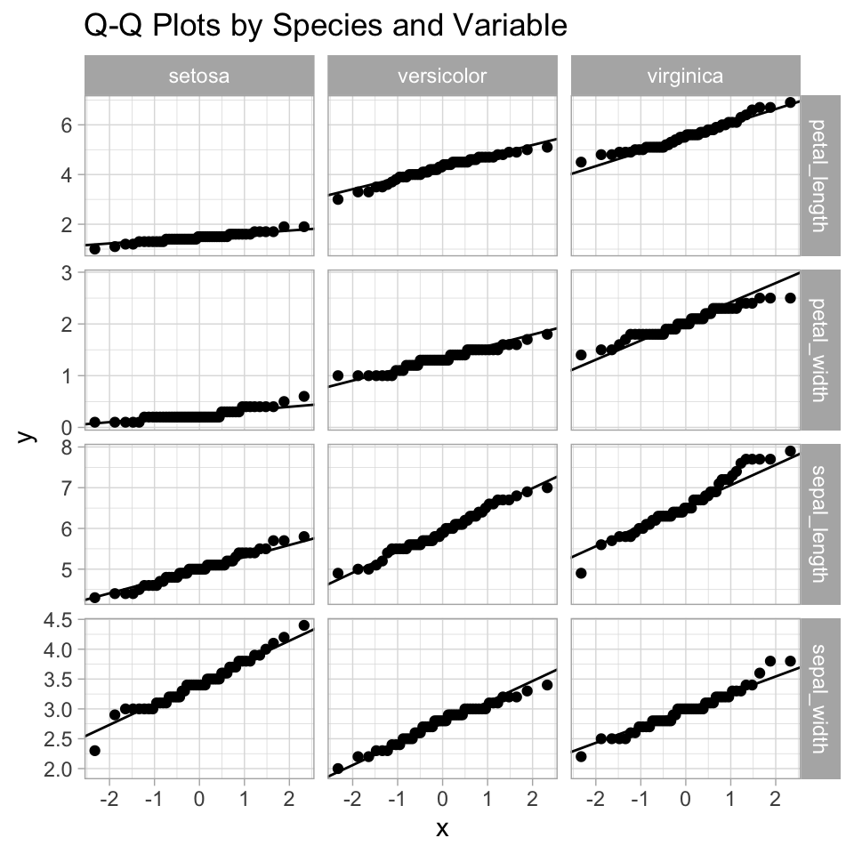

```r
# Create Q-Q plots for each variable by species
iris_long <- iris_df %>%
  pivot_longer(cols = c(sepal_length, sepal_width, petal_length, petal_width),
               names_to = "variable",
               values_to = "value")

iris_long %>%
  ggplot(aes(sample = value)) +
  geom_qq() +
  geom_qq_line() +
  facet_grid(variable ~ species, scales = "free") +
  labs(title = "Q-Q Plots by Species and Variable") +
  theme_light()
```

# MANOVA: Follow-up Univariate ANOVAs

## Follow-up Univariate ANOVAs

```r
# Univariate ANOVAs for each response variable

# Sepal Length ANOVA
sepal_length_aov <- aov(sepal_length ~ species, data = iris_df)
summary(sepal_length_aov)
```

```
             Df Sum Sq Mean Sq F value Pr(>F)
species       2  63.21  31.606   119.3 <2e-16 ***
Residuals   147  38.96   0.265
---
Signif. codes:  0 '***' 0.001 '**' 0.01 '*' 0.05 '.' 0.1 ' ' 1
```

```r
# Sepal Width ANOVA
sepal_width_aov <- aov(sepal_width ~ species, data = iris_df)
summary(sepal_width_aov)
```

```
             Df Sum Sq Mean Sq F value Pr(>F)
species       2  11.35   5.672   49.16 <2e-16 ***
Residuals   147  16.96   0.115
---
Signif. codes:  0 '***' 0.001 '**' 0.01 '*' 0.05 '.' 0.1 ' ' 1
```

```r
# Petal Length ANOVA
petal_length_aov <- aov(petal_length ~ species, data = iris_df)
summary(petal_length_aov)
```

```
             Df Sum Sq Mean Sq F value Pr(>F)
species       2  437.1  218.55    1180 <2e-16 ***
Residuals   147   27.2    0.19
---
Signif. codes:  0 '***' 0.001 '**' 0.01 '*' 0.05 '.' 0.1 ' ' 1
```

```r
# Petal Width ANOVA
petal_width_aov <- aov(petal_width ~ species, data = iris_df)
summary(petal_width_aov)
```

```
             Df Sum Sq Mean Sq F value Pr(>F)
species       2  80.41   40.21     960 <2e-16 ***
Residuals   147   6.16    0.04
---
Signif. codes:  0 '***' 0.001 '**' 0.01 '*' 0.05 '.' 0.1 ' ' 1
```

# MANOVA: Post-hoc Comparisons

## Post-hoc Comparisons using emmeans

```r
# Sepal Length comparisons
print("Sepal Length comparisons")
```

```
[1] "Sepal Length comparisons"
```

```r
sepal_length_emm <- emmeans(sepal_length_aov, ~ species)
pairs(sepal_length_emm)
```

```
 contrast               estimate    SE  df t.ratio p.value
 setosa - versicolor      -0.930 0.103 147  -9.033  <.0001
 setosa - virginica       -1.582 0.103 147 -15.366  <.0001
 versicolor - virginica   -0.652 0.103 147  -6.333  <.0001

P value adjustment: tukey method for comparing a family of 3 estimates
```

```r
# Sepal Width comparisons
print("Sepal Width comparisons")
```

```
[1] "Sepal Width comparisons"
```

```r
sepal_width_emm <- emmeans(sepal_width_aov, ~ species)
pairs(sepal_width_emm)
```

```
 contrast               estimate     SE  df t.ratio p.value
 setosa - versicolor       0.658 0.0679 147   9.685  <.0001
 setosa - virginica        0.454 0.0679 147   6.683  <.0001
 versicolor - virginica   -0.204 0.0679 147  -3.003  0.0088

P value adjustment: tukey method for comparing a family of 3 estimates
```

```r
# Petal Length comparisons
print("Petal Length comparisons")
```

```
[1] "Petal Length comparisons"
```

```r
petal_length_emm <- emmeans(petal_length_aov, ~ species)
pairs(petal_length_emm)
```

```
 contrast               estimate     SE  df t.ratio p.value
 setosa - versicolor       -2.80 0.0861 147 -32.510  <.0001
 setosa - virginica        -4.09 0.0861 147 -47.521  <.0001
 versicolor - virginica    -1.29 0.0861 147 -15.012  <.0001

P value adjustment: tukey method for comparing a family of 3 estimates
```

```r
# Petal Width comparisons
print("Petal Width comparisons")
```

```
[1] "Petal Width comparisons"
```

```r
petal_width_emm <- emmeans(petal_width_aov, ~ species)
pairs(petal_width_emm)
```

```
 contrast               estimate     SE  df t.ratio p.value
 setosa - versicolor       -1.08 0.0409 147 -26.387  <.0001
 setosa - virginica        -1.78 0.0409 147 -43.489  <.0001
 versicolor - virginica    -0.70 0.0409 147 -17.102  <.0001

P value adjustment: tukey method for comparing a family of 3 estimates
```

# Canonical Discriminant Analysis: Eigenvalues

## Eigenvalues and Canonical Variates

```r
# Perform canonical discriminant analysis
iris_candisc <- candisc(iris_manova_model)

# Display eigenvalues and canonical correlations
cat("Canonical Discriminant Analysis Results:\n\n")
```

```
Canonical Discriminant Analysis Results:
```

```r
print(iris_candisc)
```

```
Canonical Discriminant Analysis for species:

   CanRsq Eigenvalue Difference  Percent Cumulative
1 0.96987   32.19193     31.907 99.12126     99.121
2 0.22203    0.28539     31.907  0.87874    100.000

Test of H0: The canonical correlations in the
current row and all that follow are zero

  LR test stat approx F numDF denDF   Pr(> F)
1      0.02344  199.145     8   288 < 2.2e-16 ***
2      0.77797   13.794     3   145 5.794e-08 ***
---
Signif. codes:  0 '***' 0.001 '**' 0.01 '*' 0.05 '.' 0.1 ' ' 1
```

```r
# Extract eigenvalues
eigenvalues <- iris_candisc$eigenvalues
cat("\nEigenvalues:\n")
```

```
Eigenvalues:
```

```r
print(eigenvalues)
```

```
[1]  3.219193e+01  2.853910e-01 -7.801056e-17 -1.398429e-15
```

```r
# Calculate proportion of variance explained
prop_variance <- eigenvalues / sum(eigenvalues)
cat("\nProportion of variance explained by each canonical variate:\n")
```

```
Proportion of variance explained by each canonical variate:
```

```r
print(prop_variance)
```

```
[1]  9.912126e-01  8.787395e-03 -2.402001e-18 -4.305862e-17
```

```r
# Cumulative proportion
cumulative_prop <- cumsum(prop_variance)
cat("\nCumulative proportion of variance explained:\n")
```

```
Cumulative proportion of variance explained:
```

```r
print(cumulative_prop)
```

```
[1] 0.9912126 1.0000000 1.0000000 1.0000000
```

# Canonical Discriminant Analysis: Coefficients

## Canonical Coefficients (Eigenvectors)

```r
# Display canonical coefficients (eigenvectors)
cat("Raw Canonical Coefficients (Eigenvectors):\n")
```

```
Raw Canonical Coefficients (Eigenvectors):
```

```r
print(iris_candisc$coeffs.raw)
```

```
                   Can1        Can2
sepal_length  0.8293776  0.02410215
sepal_width   1.5344731  2.16452123
petal_length -2.2012117 -0.93192121
petal_width  -2.8104603  2.83918785
```

```r
cat("\nStandardized Canonical Coefficients:\n")
```

```
Standardized Canonical Coefficients:
```

```r
print(iris_candisc$coeffs.std)
```

```
                   Can1        Can2
sepal_length  0.4269548  0.01240753
sepal_width   0.5212417  0.73526131
petal_length -0.9472572 -0.40103782
petal_width  -0.5751608  0.58103986
```

```r
# Structure coefficients (correlations between original variables and canonical variates)
cat("\nStructure Coefficients (Variable-Canonical Variate Correlations):\n")
```

```
Structure Coefficients (Variable-Canonical Variate Correlations):
```

```r
print(iris_candisc$structure)
```

```
                   Can1       Can2
sepal_length -0.7918878 0.21759312
sepal_width   0.5307590 0.75798931
petal_length -0.9849513 0.04603709
petal_width  -0.9728120 0.22290236
```

# Multivariate Visualization

Multivariate Visualization

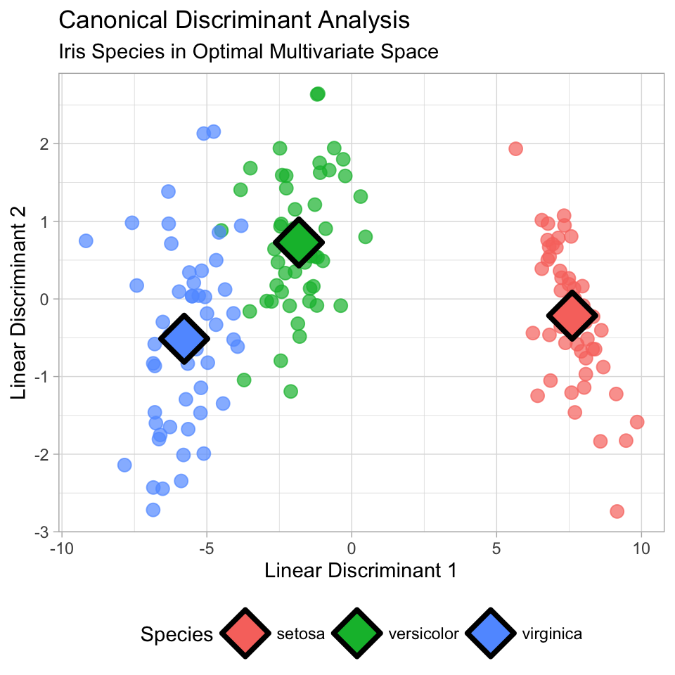

```r
# Extract canonical scores using the correct method

# Alternative simpler approach - use lda from MASS package
# library(MASS)
iris_lda <- MASS::lda(species ~ sepal_length + sepal_width + petal_length + petal_width, data = iris_df)
lda_pred <- predict(iris_lda)

# Create dataframe with LDA scores (equivalent to canonical scores)
canonical_df_plot <- data.frame(
  Can1 = lda_pred$x[, 1],
  Can2 = lda_pred$x[, 2],
  species = iris_df$species
)

# Calculate group centroids
centroids_plot <- canonical_df_plot %>%
  group_by(species) %>%
  summarise(Can1_mean = mean(Can1),
            Can2_mean = mean(Can2),
            .groups = 'drop')

# Create ggplot
canonical_df_plot %>%
  ggplot(aes(x = Can1, y = Can2, color = species)) +
  geom_point(size = 3, alpha = 0.7) +
  geom_point(data = centroids_plot,
             aes(x = Can1_mean, y = Can2_mean, fill = species),
             shape = 23, color = "black", size = 8, stroke = 2) +
  labs(title = "Canonical Discriminant Analysis",
       subtitle = "Iris Species in Optimal Multivariate Space",
       x = "Linear Discriminant 1",
       y = "Linear Discriminant 2",
       color = "Species",
       fill = "Species") +
  theme_light() +
  theme(legend.position = "bottom")
```

# MANOVA Results: Key Interpretation

## Key Interpretation

**Pillai’s Trace (1.1919)**: This is large, indicating substantial group differences across the multivariate space.

**F-statistic (53.466)**: Very large F-value indicates strong evidence against the null hypothesis.

**P-value**: Essentially zero, meaning we reject the null hypothesis that all three species have the same multivariate means.

**Conclusion**: The three iris species are significantly different when considering all four morphological measurements simultaneously in multivariate space.

```r
# MANOVA Test Results
summary(iris_manova_model)
```

```
           Df Pillai approx F num Df den Df    Pr(>F)
species     2 1.1919   53.466      8    290 < 2.2e-16 ***
Residuals 147
---
Signif. codes:  0 '***' 0.001 '**' 0.01 '*' 0.05 '.' 0.1 ' ' 1
```

# MANOVA Results: Wilks’ Lambda

### Interpretation of MANOVA

**Wilks’ Lambda (0.023439)**: Very small value (close to 0) indicates:

- Only about 2.3% of the total variance is unexplained by group differences
- About 97.7% of the multivariate variance is explained by species differences
- Extremely strong group separation in multivariate space

**Effect Size**: Partial η² ≈ 1 - 0.023439 = 0.977 (very large effect size)

**F-statistic (199.15)**: Much larger than Pillai’s F-value because Wilks’ Lambda is often more powerful when assumptions are met

**Conclusion**: The three iris species show extremely large multivariate differences - they are very well separated in the 4-dimensional morphological space, with species explaining nearly 98% of the multivariate variance.

**Wilks’ vs Pillai’s**: Wilks’ Lambda is generally preferred when assumptions are met, while Pillai’s trace is more robust to assumption violations.

```r
# Get Wilks' Lambda from manova for effect size
manova_summary <- summary(iris_manova_model, test = "Wilks")
manova_summary
```

```
           Df    Wilks approx F num Df den Df    Pr(>F)
species     2 0.023439   199.15      8    288 < 2.2e-16 ***
Residuals 147
---
Signif. codes:  0 '***' 0.001 '**' 0.01 '*' 0.05 '.' 0.1 ' ' 1
```

# MANOVA Results: Effect Size

### Interpretation of MANOVA

**Meaning**: Approximately 97.7% of the total multivariate variance is explained by species differences.

**Effect Size Guidelines:** - **Small effect**: η² ≈ 0.01 (1% of variance explained) - **Medium effect**: η² ≈ 0.06 (6% of variance explained) - **Large effect**: η² ≈ 0.14 (14% of variance explained) - **Our result**: η² = 0.977 (**extremely large effect**)

**Practical Interpretation:** - Species are almost perfectly separated in multivariate morphological space - Only 2.3% of the variation in the four measurements is due to within-species differences - Species membership explains nearly all the multivariate variation - This represents one of the strongest group separations possible in real biological data

```r
# Effect Size (Partial Eta-squared approximation)
wilks_lambda <- manova_summary$stats[1, "Wilks"]
partial_eta_sq <- 1 - wilks_lambda
partial_eta_sq
```

```
[1] 0.9765614
```

# Canonical Variates: Variance Explained

### Interpretation of manova

**Element [1] = 0.9912**: - First canonical variate explains 99.12% of the between-group variance - This dimension captures almost all the multivariate group differences

**Element [2] = 0.0088**: - Second canonical variate explains 0.88% of the between-group variance - This dimension captures the remaining small group differences

## Interpretation

**Dimensionality**: The group differences are essentially **one-dimensional** - 99% of separation occurs along the first canonical axis.

**Biological Meaning**: There’s one primary “direction” in morphological space that best separates the three iris species, with a very minor secondary pattern.

**Practical Implication**: You could visualize almost all the group separation using just the first canonical variate, though plotting both dimensions shows the complete picture.

```r
# Canonical Analysis Summary
prop_variance
```

```
[1]  9.912126e-01  8.787395e-03 -2.402001e-18 -4.305862e-17
```

```r
sum(prop_variance)
```

```
[1] 1
```

# Linear Discriminant Analysis: Detailed Results

### Interpretation of manova

Group means: - **Setosa**: Smallest overall, widest sepals, tiny petals - **Versicolor**: Medium-sized in most dimensions - **Virginica**: Largest overall, especially in petal dimensions - Clear size progression: setosa < versicolor < virginica

Proportion of trace: - **LD1**: Explains 99.12% of between-group discrimination - **LD2**: Explains 0.88% of between-group discrimination - Confirms the separation is essentially one-dimensional (petal vs sepal contrast)

```r
# LDA results for interpretation
iris_lda
```

```
Call:
lda(species ~ sepal_length + sepal_width + petal_length + petal_width,
    data = iris_df)

Prior probabilities of groups:
    setosa versicolor  virginica
 0.3333333  0.3333333  0.3333333

Group means:
           sepal_length sepal_width petal_length petal_width
setosa            5.006       3.428        1.462       0.246
versicolor        5.936       2.770        4.260       1.326
virginica         6.588       2.974        5.552       2.026

Coefficients of linear discriminants:
                    LD1         LD2
sepal_length  0.8293776 -0.02410215
sepal_width   1.5344731 -2.16452123
petal_length -2.2012117  0.93192121
petal_width  -2.8104603 -2.83918785

Proportion of trace:
   LD1    LD2
0.9912 0.0088
```

# MANOVA Advantages over Multiple ANOVAs

## Advantages of MANOVA over Multiple ANOVAs

### Statistical Advantages

- Controls family-wise error rate (no need for Bonferroni correction)
- Accounts for correlations between response variables
- More powerful when variables are correlated
- Tests the ‘global’ null hypothesis

### Interpretational Advantages

- Reveals patterns in multivariate space that univariate tests miss
- Canonical variates show optimal linear combinations for group separation
- Provides insight into which variables work together to discriminate groups
- Shows the dimensionality of group differences

### Biological Relevance

- Organisms function as integrated wholes, not independent traits
- Natural selection acts on trait combinations, not isolated traits
- Multivariate approaches better reflect biological reality

Back to top